# DARE-Newcrest data challenge - flotation plant dataset

DARE 2022

In this R Markdown file, we will provide a template for the DARE-Newcrest data challenge. The main steps covered here will be:

- Load the data
- Provide an overview of what is in the data
- Provide an example of a terribly performing baseline model
- Provide functions to quantify model predictive performance

### Imports and settings

Everything we need to get started.

```r
script_path_current <- funr::get_script_path()
source(Gmisc::pathJoin(script_path_current, "functions_R", "R_data_functions.R"), local = knitr::knit_global())
source(Gmisc::pathJoin(script_path_current, "functions_R", "R_helper_functions.R"), local = knitr::knit_global())
source(Gmisc::pathJoin(script_path_current, "functions_R", "R_plotting_functions.R"), local = knitr::knit_global())
```

### Load the data

Briefly look at the contents and structure of the data.

```r
process_data <- load_raw_data()
head(process_data)
```

| date | % Iron Feed | % Silica Feed | Starch Flow | Amina Flow | Ore Pulp Flow | Ore Pulp pH | Ore Pulp Density | Flotation Column 01 Air Flow | Flotation Column 02 Air Flow | Flotation Column 03 Air Flow | Flotation Column 04 Air Flow | Flotation Column 05 Air Flow | Flotation Column 06 Air Flow | Flotation Column 07 Air Flow | Flotation Column 01 Level | Flotation Column 02 Level | Flotation Column 03 Level | Flotation Column 04 Level | Flotation Column 05 Level | Flotation Column 06 Level | Flotation Column 07 Level | % Iron Concentrate | % Silica Concentrate |
| --- | --- | --- | --- | --- | --- | --- | --- | --- | --- | --- | --- | --- | --- | --- | --- | --- | --- | --- | --- | --- | --- | --- | --- |
| 2017-03-10 01:00:00 | 55.2 | 16.98 | 3019.53 | 557.434 | 395.713 | 10.0664 | 1.74 | 249.214 | 253.235 | 250.576 | 295.096 | 306.4 | 250.225 | 250.884 | 457.396 | 432.962 | 424.954 | 443.558 | 502.255 | 446.370 | 523.344 | 66.91 | 1.31 |
| 2017-03-10 01:00:00 | 55.2 | 16.98 | 3024.41 | 563.965 | 397.383 | 10.0672 | 1.74 | 249.719 | 250.532 | 250.862 | 295.096 | 306.4 | 250.137 | 248.994 | 451.891 | 429.560 | 432.939 | 448.086 | 496.363 | 445.922 | 498.075 | 66.91 | 1.31 |
| 2017-03-10 01:00:00 | 55.2 | 16.98 | 3043.46 | 568.054 | 399.668 | 10.0680 | 1.74 | 249.741 | 247.874 | 250.313 | 295.096 | 306.4 | 251.345 | 248.071 | 451.240 | 468.927 | 434.610 | 449.688 | 484.411 | 447.826 | 458.567 | 66.91 | 1.31 |
| 2017-03-10 01:00:00 | 55.2 | 16.98 | 3047.36 | 568.665 | 397.939 | 10.0689 | 1.74 | 249.917 | 254.487 | 250.049 | 295.096 | 306.4 | 250.422 | 251.147 | 452.441 | 458.165 | 442.865 | 446.210 | 471.411 | 437.690 | 427.669 | 66.91 | 1.31 |
| 2017-03-10 01:00:00 | 55.2 | 16.98 | 3033.69 | 558.167 | 400.254 | 10.0697 | 1.74 | 250.203 | 252.136 | 249.895 | 295.096 | 306.4 | 249.983 | 248.928 | 452.441 | 452.900 | 450.523 | 453.670 | 462.598 | 443.682 | 425.679 | 66.91 | 1.31 |
| 2017-03-10 01:00:00 | 55.2 | 16.98 | 3079.10 | 564.697 | 396.533 | 10.0705 | 1.74 | 250.730 | 248.906 | 249.521 | 295.096 | 306.4 | 250.356 | 251.873 | 444.384 | 443.269 | 460.449 | 439.920 | 451.588 | 433.539 | 425.458 | 66.91 | 1.31 |

```r
# lets look at some properties of the data
cat("Number of features: ", ncol(process_data),
    "\nNumber of observations: ", nrow(process_data),
    "\nVariable names: ", paste0('"', colnames(process_data), '"  '),
    sep = "")
```

```
## Number of features: 24
## Number of observations: 737453
## Variable names: "date"  "% Iron Feed"  "% Silica Feed"  "Starch Flow"  "Amina Flow"  "Ore Pulp Flow"  "Ore Pulp pH"  "Ore Pulp Density"  "Flotation Column 01 Air Flow"  "Flotation Column 02 Air Flow"  "Flotation Column 03 Air Flow"  "Flotation Column 04 Air Flow"  "Flotation Column 05 Air Flow"  …
```

```r
Hmisc::html(Hmisc::describe(process_data))
```

process_data  
24 Variables 737453 Observations

date

```
                   n             missing            distinct                Info
              737453                   0                4097                   1
                Mean                 Gmd                 .05                 .10
 2017-06-16 03:27:22             4996587 2017-03-31 19:00:00 2017-04-09 08:00:00
                 .25                 .50                 .75                 .90
 2017-05-04 23:00:00 2017-06-16 15:00:00 2017-07-29 07:00:00 2017-08-23 22:00:00
                 .95
 2017-09-01 11:00:00
```

| lowest : | 2017-03-10 01:00:00 | 2017-03-10 02:00:00 | 2017-03-10 03:00:00 | 2017-03-10 04:00:00 | 2017-03-10 05:00:00 |
| --- | --- | --- | --- | --- | --- |
| highest: | 2017-09-09 19:00:00 | 2017-09-09 20:00:00 | 2017-09-09 21:00:00 | 2017-09-09 22:00:00 | 2017-09-09 23:00:00 |

% Iron Feed

| n | missing | distinct | Info | Mean | Gmd | .05 | .10 | .25 | .50 | .75 | .90 | .95 |
| --- | --- | --- | --- | --- | --- | --- | --- | --- | --- | --- | --- | --- |
| 737453 | 0 | 278 | 0.992 | 56.29 | 5.849 | 48.21 | 48.81 | 52.67 | 56.08 | 59.72 | 64.03 | 64.03 |

lowest : 42.74 43.37 44.70 44.90 45.38 , highest: 63.64 64.03 64.46 64.48 65.78

% Silica Feed

| n | missing | distinct | Info | Mean | Gmd | .05 | .10 | .25 | .50 | .75 | .90 | .95 |
| --- | --- | --- | --- | --- | --- | --- | --- | --- | --- | --- | --- | --- |
| 737453 | 0 | 293 | 0.992 | 14.65 | 7.725 | 6.26 | 6.26 | 8.94 | 13.85 | 19.60 | 25.31 | 26.83 |

lowest : 1.31 2.77 3.77 3.85 4.20 , highest: 30.14 30.37 30.90 32.23 33.40

Starch Flow

| n | missing | distinct | Info | Mean | Gmd | .05 | .10 | .25 | .50 | .75 | .90 | .95 |
| --- | --- | --- | --- | --- | --- | --- | --- | --- | --- | --- | --- | --- |
| 737453 | 0 | 409317 | 1 | 2869 | 1374 | 607 | 1034 | 2076 | 3018 | 3728 | 4296 | 4699 |

| lowest : | 2.02596e-03 | 6.61397e-03 | 7.65623e-03 | 8.88006e-03 | 1.32302e-02 |
| --- | --- | --- | --- | --- | --- |
| highest: | 6.29708e+03 | 6.29710e+03 | 6.29946e+03 | 6.29988e+03 | 6.30023e+03 |

Amina Flow

| n | missing | distinct | Info | Mean | Gmd | .05 | .10 | .25 | .50 | .75 | .90 | .95 |
| --- | --- | --- | --- | --- | --- | --- | --- | --- | --- | --- | --- | --- |
| 737453 | 0 | 319416 | 1 | 488.1 | 101.6 | 307.1 | 360.7 | 431.8 | 504.4 | 553.3 | 590.5 | 609.2 |

lowest : 241.6690 241.6880 241.6940 241.6990 241.6992 , highest: 739.4550 739.4570 739.4890 739.5040 739.5380

Ore Pulp Flow

| n | missing | distinct | Info | Mean | Gmd | .05 | .10 | .25 | .50 | .75 | .90 | .95 |
| --- | --- | --- | --- | --- | --- | --- | --- | --- | --- | --- | --- | --- |
| 737453 | 0 | 180189 | 1 | 397.6 | 10.58 | 378.5 | 380.5 | 394.3 | 399.2 | 403.0 | 407.7 | 413.9 |

lowest : 376.249 376.250 376.251 376.252 376.253 , highest: 418.637 418.638 418.639 418.640 418.641

Ore Pulp pH

```
        n  missing distinct     Info     Mean      Gmd      .05      .10      .25
   737453        0   131143        1    9.768   0.4346    9.033    9.255    9.527
      .50      .75      .90      .95
    9.798   10.038   10.234   10.352
```

lowest : 8.75334 8.75337 8.75337 8.75337 8.75337 , highest: 10.80799 10.80803 10.80805 10.80806 10.80810

Ore Pulp Density

| n | missing | distinct | Info | Mean | Gmd | .05 | .10 | .25 | .50 | .75 | .90 | .95 |
| --- | --- | --- | --- | --- | --- | --- | --- | --- | --- | --- | --- | --- |
| 737453 | 0 | 105805 | 1 | 1.68 | 0.07565 | 1.522 | 1.561 | 1.647 | 1.698 | 1.728 | 1.753 | 1.768 |

lowest : 1.519820 1.519823 1.519826 1.519829 1.519830 , highest: 1.853207 1.853218 1.853229 1.853239 1.853250

Flotation Column 01 Air Flow

| n | missing | distinct | Info | Mean | Gmd | .05 | .10 | .25 | .50 | .75 | .90 | .95 |
| --- | --- | --- | --- | --- | --- | --- | --- | --- | --- | --- | --- | --- |
| 737453 | 0 | 43675 | 1 | 280.2 | 28.23 | 238.7 | 249.4 | 250.3 | 299.3 | 300.1 | 300.8 | 301.4 |

lowest : 175.5100 175.5580 175.6190 175.6663 175.6980 , highest: 372.3876 372.4426 372.6840 373.5490 373.8710

Flotation Column 02 Air Flow

| n | missing | distinct | Info | Mean | Gmd | .05 | .10 | .25 | .50 | .75 | .90 | .95 |
| --- | --- | --- | --- | --- | --- | --- | --- | --- | --- | --- | --- | --- |
| 737453 | 0 | 80442 | 1 | 277.2 | 31.3 | 222.1 | 246.7 | 250.5 | 296.2 | 300.7 | 303.5 | 305.3 |

lowest : 175.156 175.263 175.590 175.655 175.824 , highest: 375.653 375.654 375.776 375.965 375.992

Flotation Column 03 Air Flow

| n | missing | distinct | Info | Mean | Gmd | .05 | .10 | .25 | .50 | .75 | .90 | .95 |
| --- | --- | --- | --- | --- | --- | --- | --- | --- | --- | --- | --- | --- |
| 737453 | 0 | 40630 | 1 | 281.1 | 27.44 | 246.9 | 248.9 | 250.9 | 298.7 | 300.4 | 301.9 | 302.3 |

lowest : 176.4690 176.4719 176.4748 176.4778 176.4807 , highest: 360.5860 361.0064 362.0642 363.1220 364.3460

Flotation Column 04 Air Flow

| n | missing | distinct | Info | Mean | Gmd | .05 | .10 | .25 | .50 | .75 | .90 | .95 |
| --- | --- | --- | --- | --- | --- | --- | --- | --- | --- | --- | --- | --- |
| 737453 | 0 | 196006 | 0.999 | 299.4 | 2.813 | 295.1 | 295.1 | 298.3 | 299.8 | 300.6 | 302.5 | 304.4 |

lowest : 292.1950 292.2180 292.2280 292.2360 292.3620 , highest: 305.8587 305.8590 305.8640 305.8680 305.8710

Flotation Column 05 Air Flow

| n | missing | distinct | Info | Mean | Gmd | .05 | .10 | .25 | .50 | .75 | .90 | .95 |
| --- | --- | --- | --- | --- | --- | --- | --- | --- | --- | --- | --- | --- |
| 737453 | 0 | 194711 | 0.999 | 299.9 | 3.97 | 293.5 | 295.7 | 298.1 | 299.9 | 301.8 | 306.4 | 306.4 |

lowest : 286.2950 286.3690 286.5411 286.7132 286.7470 , highest: 310.0660 310.0730 310.1170 310.1230 310.2700

Flotation Column 06 Air Flow

| n | missing | distinct | Info | Mean | Gmd | .05 | .10 | .25 | .50 | .75 | .90 | .95 |
| --- | --- | --- | --- | --- | --- | --- | --- | --- | --- | --- | --- | --- |
| 737453 | 0 | 90548 | 1 | 292.1 | 31.44 | 248.8 | 249.9 | 262.5 | 299.5 | 303.1 | 333.6 | 349.8 |

lowest : 189.928 190.146 190.219 190.502 190.536 , highest: 370.899 370.903 370.908 370.909 370.910

Flotation Column 07 Air Flow

| n | missing | distinct | Info | Mean | Gmd | .05 | .10 | .25 | .50 | .75 | .90 | .95 |
| --- | --- | --- | --- | --- | --- | --- | --- | --- | --- | --- | --- | --- |
| 737453 | 0 | 86819 | 1 | 290.8 | 29.45 | 248.5 | 249.6 | 256.3 | 299.0 | 301.9 | 310.6 | 348.9 |

lowest : 185.9620 185.9810 186.0275 186.0540 186.0741 , highest: 371.5730 371.5870 371.5900 371.5920 371.5930

Flotation Column 01 Level

| n | missing | distinct | Info | Mean | Gmd | .05 | .10 | .25 | .50 | .75 | .90 | .95 |
| --- | --- | --- | --- | --- | --- | --- | --- | --- | --- | --- | --- | --- |
| 737453 | 0 | 299573 | 1 | 520.2 | 140.4 | 385.5 | 393.9 | 417.0 | 491.9 | 594.1 | 759.6 | 811.2 |

lowest : 149.2180 149.2930 149.3220 149.3868 149.4410 , highest: 862.2205 862.2290 862.2430 862.2720 862.2740

Flotation Column 02 Level

| n | missing | distinct | Info | Mean | Gmd | .05 | .10 | .25 | .50 | .75 | .90 | .95 |
| --- | --- | --- | --- | --- | --- | --- | --- | --- | --- | --- | --- | --- |
| 737453 | 0 | 331189 | 1 | 522.6 | 138.7 | 373.3 | 397.1 | 441.9 | 496.0 | 595.5 | 754.7 | 803.5 |

lowest : 210.752 210.760 210.768 210.770 210.986 , highest: 828.847 828.870 828.894 828.903 828.919

Flotation Column 03 Level

| n | missing | distinct | Info | Mean | Gmd | .05 | .10 | .25 | .50 | .75 | .90 | .95 |
| --- | --- | --- | --- | --- | --- | --- | --- | --- | --- | --- | --- | --- |
| 737453 | 0 | 322315 | 1 | 531.4 | 162.2 | 385.0 | 394.5 | 411.3 | 494.3 | 601.2 | 802.0 | 867.7 |

lowest : 126.2550 126.2560 126.3040 126.3340 126.3520 , highest: 886.8166 886.8184 886.8185 886.8202 886.8220

Flotation Column 04 Level

| n | missing | distinct | Info | Mean | Gmd | .05 | .10 | .25 | .50 | .75 | .90 | .95 |
| --- | --- | --- | --- | --- | --- | --- | --- | --- | --- | --- | --- | --- |
| 737453 | 0 | 309264 | 1 | 420.3 | 102.2 | 284.8 | 324.8 | 356.7 | 412.0 | 485.5 | 529.4 | 580.8 |

lowest : 162.201 162.218 162.226 162.251 162.265 , highest: 680.187 680.222 680.274 680.340 680.359

Flotation Column 05 Level

| n | missing | distinct | Info | Mean | Gmd | .05 | .10 | .25 | .50 | .75 | .90 | .95 |
| --- | --- | --- | --- | --- | --- | --- | --- | --- | --- | --- | --- | --- |
| 737453 | 0 | 276051 | 1 | 425.3 | 93.48 | 324.8 | 338.4 | 357.7 | 408.8 | 484.3 | 528.7 | 590.5 |

lowest : 166.991 166.999 167.010 167.049 167.114 , highest: 675.604 675.607 675.625 675.626 675.644

Flotation Column 06 Level

| n | missing | distinct | Info | Mean | Gmd | .05 | .10 | .25 | .50 | .75 | .90 | .95 |
| --- | --- | --- | --- | --- | --- | --- | --- | --- | --- | --- | --- | --- |
| 737453 | 0 | 301502 | 1 | 429.9 | 100.6 | 302.7 | 331.2 | 358.5 | 424.7 | 492.7 | 541.7 | 598.2 |

lowest : 155.841 156.004 156.267 156.451 156.561 , highest: 698.805 698.814 698.816 698.853 698.861

Flotation Column 07 Level

| n | missing | distinct | Info | Mean | Gmd | .05 | .10 | .25 | .50 | .75 | .90 | .95 |
| --- | --- | --- | --- | --- | --- | --- | --- | --- | --- | --- | --- | --- |
| 737453 | 0 | 295667 | 1 | 421 | 94.94 | 305.1 | 330.3 | 356.8 | 411.1 | 476.5 | 530.4 | 579.9 |

lowest : 175.349 175.377 175.439 175.460 175.483 , highest: 659.768 659.772 659.883 659.900 659.902

% Iron Concentrate

| n | missing | distinct | Info | Mean | Gmd | .05 | .10 | .25 | .50 | .75 | .90 | .95 |
| --- | --- | --- | --- | --- | --- | --- | --- | --- | --- | --- | --- | --- |
| 737453 | 0 | 38696 | 1 | 65.05 | 1.257 | 62.87 | 63.40 | 64.37 | 65.21 | 65.86 | 66.37 | 66.61 |

lowest : 62.05000 62.05222 62.05368 62.05444 62.05501 , highest: 67.63000 67.66000 67.67000 67.99000 68.01000

% Silica Concentrate

| n | missing | distinct | Info | Mean | Gmd | .05 | .10 | .25 | .50 | .75 | .90 | .95 |
| --- | --- | --- | --- | --- | --- | --- | --- | --- | --- | --- | --- | --- |
| 737453 | 0 | 55569 | 1 | 2.327 | 1.226 | 1.08 | 1.18 | 1.44 | 2.00 | 3.01 | 4.14 | 4.73 |

lowest : 0.600000 0.660000 0.740000 0.750000 0.770000 , highest: 5.529187 5.529390 5.529593 5.529797 5.530000

### Dataset description

Our task is to predict the `% Silica Concentrate` based on the available features.

From [the Kaggle page:](https://www.kaggle.com/datasets/edumagalhaes/quality-prediction-in-a-mining-process?datasetId=6294&sortBy=voteCount)

“The first column shows time and date range (from march of 2017 until september of 2017). Some columns were sampled every 20 second. Others were sampled on a hourly basis.

The second and third columns are quality measures of the iron ore pulp right before it is fed into the flotation plant. Column 4 until column 8 are the most important variables that impact in the ore quality in the end of the process. From column 9 until column 22, we can see process data (level and air flow inside the flotation columns, which also impact in ore quality. The last two columns are the final iron ore pulp quality measurement from the lab.

Target is to predict the last column, which is the % of silica in the iron ore concentrate.”

We have hourly values for:

- `% Iron Feed`
- `% Silica Feed`
- `% Iron Concentrate`
- `% Silica Concentrate`

Cleaning: I am not sure of the interpolation that might have been done before these data were posted online, I have removed a long run of constant values (‘2017-07-31 20:00’:‘2017-08-03 20:00’), I will use this is as a split between training and test data. I have also just thrown out the data up to late March, as people may want to apply timeseries approaches. There are still a lot of smaller stretches of what looks to be problematic data (I think someone has interpolated across null values).

```r
# First of all lets resample hourly taking the mean of each of the process variables
hourly_data <- select(
  process_data %>%
  mutate(hour = lubridate::floor_date(date, "hour")) %>%
  group_by(hour) %>%
  summarise(
    "date" = mean(date),
    "% Iron Feed" = mean(`% Iron Feed`),
    "% Silica Feed" = mean(`% Silica Feed`),
    "Starch Flow" = mean(`Starch Flow`),
    "Amina Flow" = mean(`Amina Flow`),
    "Ore Pulp Flow" = mean(`Ore Pulp Flow`),
    "Ore Pulp pH" = mean(`Ore Pulp pH`),
    "Ore Pulp Density" = mean(`Ore Pulp Density`),
    "Flotation Column 01 Air Flow" = mean(`Flotation Column 01 Air Flow`),
    "Flotation Column 02 Air Flow" = mean(`Flotation Column 02 Air Flow`),
    "Flotation Column 03 Air Flow" = mean(`Flotation Column 03 Air Flow`),
    "Flotation Column 04 Air Flow" = mean(`Flotation Column 04 Air Flow`),
    "Flotation Column 05 Air Flow" = mean(`Flotation Column 05 Air Flow`),
    "Flotation Column 06 Air Flow" = mean(`Flotation Column 06 Air Flow`),
    "Flotation Column 07 Air Flow" = mean(`Flotation Column 07 Air Flow`),
    "Flotation Column 01 Level" = mean(`Flotation Column 01 Level`),
    "Flotation Column 02 Level" = mean(`Flotation Column 02 Level`),
    "Flotation Column 03 Level" = mean(`Flotation Column 03 Level`),
    "Flotation Column 04 Level" = mean(`Flotation Column 04 Level`),
    "Flotation Column 05 Level" = mean(`Flotation Column 05 Level`),
    "Flotation Column 06 Level" = mean(`Flotation Column 06 Level`),
    "Flotation Column 07 Level" = mean(`Flotation Column 07 Level`),
    "% Iron Concentrate" = mean(`% Iron Concentrate`),
    "% Silica Concentrate" = mean(`% Silica Concentrate`)),
  -1)

hourly_data$"% Silica Concentrate"[between(hourly_data$date,
                                           lubridate::ymd_hm("2017-07-31 20:00"),
                                           lubridate::ymd_hm("2017-08-03 20:00"))] <- NA
cat("Number of hourly observations: ",
    nrow(tidyr::drop_na(hourly_data)), " of ", nrow(hourly_data), sep = "")
```

```
## Number of hourly observations: 4024 of 4097
```

Training data

```r
train_data <- filter(hourly_data, between(date,
  lubridate::ymd_hms("2017-03-29 12:00:00"),
  lubridate::ymd_hms("2017-07-31 19:00:00"))
)
cat("Training data is around ",
    round(nrow(train_data) / nrow(hourly_data) * 100, 2),
    "% of the total data",
    "\nTraining - number of hourly observations: ",
    nrow(tidyr::drop_na(train_data)), " of ", nrow(train_data), sep = "")
```

```
## Training data is around 72.83% of the total data
## Training - number of hourly observations: 2984 of 2984
```

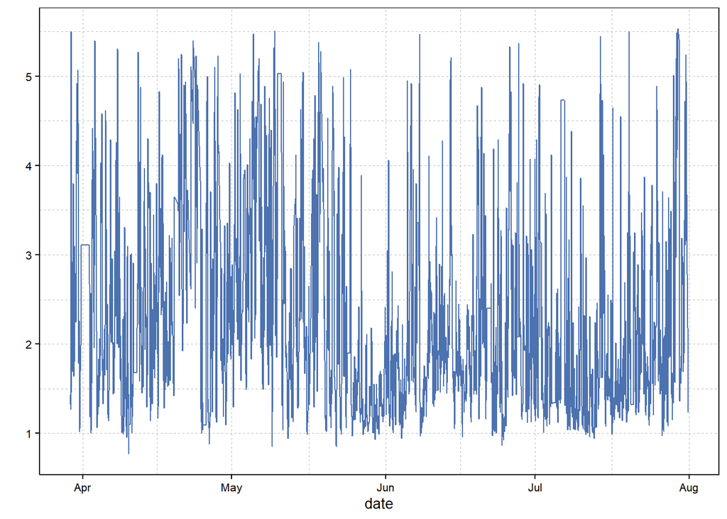

```r
ggplot(train_data, aes(x = date, y = `% Silica Concentrate`)) +
  geom_line(color = "#4c72b0") +
  xlab("date") +
  ylab("") +
  theme_dare()
```

Test data

```r
# now split the test data - conveniently about 20%
test_data <- filter(hourly_data, date >= lubridate::ymd_hm("2017-08-03 21:00"))
cat("Test data is around ",
    round(nrow(test_data) / nrow(hourly_data) * 100, 2),
    "% of the total data",
    "\nTest - number of hourly observations: ",
    nrow(tidyr::drop_na(test_data)), " of ", nrow(test_data), sep = "")
```

```
## Test data is around 21.75% of the total data
## Test - number of hourly observations: 891 of 891
```

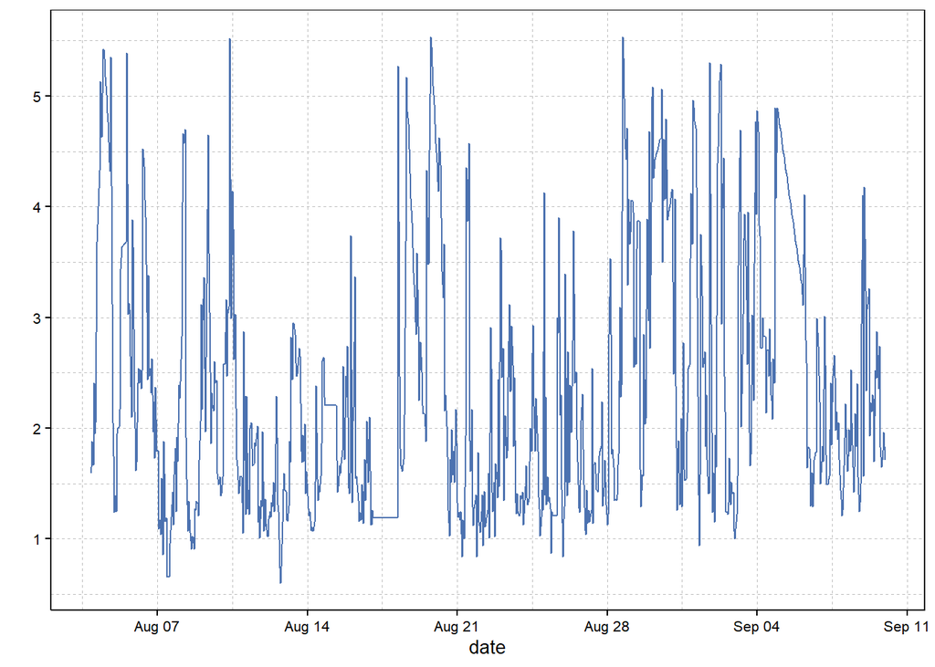

```r
# quick plot
ggplot(test_data, aes(x = date, y = `% Silica Concentrate`)) +
  geom_line(color = "#4c72b0") +
  xlab("date") +
  ylab("") +
  theme_dare()
```

```r
# Lets now save the training and test data as hourly mean
data.table::fwrite(train_data, Gmisc::pathJoin(script_path_current, "data", "hourly_train_data_R.csv"))
data.table::fwrite(test_data, Gmisc::pathJoin(script_path_current, "data", "hourly_test_data_R.csv"))
```